# Your Turn Solutions

## Motivating Example

1. Get a summary of the daily shedding values (use the shed data set)

```r
#shed <- read_csv("https://unl-statistics.github.io/R-workshops/01-r-intro/data/daily_shedding.csv")

shed <- read.csv("../data/daily_shedding.csv")


summary(shed$daily_shedding)
```

```
##    Min. 1st Qu.  Median    Mean 3rd Qu.    Max.
##   0.000   0.000   3.912   3.765   5.521  13.218
```

2. Make side by side boxplots of final weight gain by treatment group (use the final_shed data set)

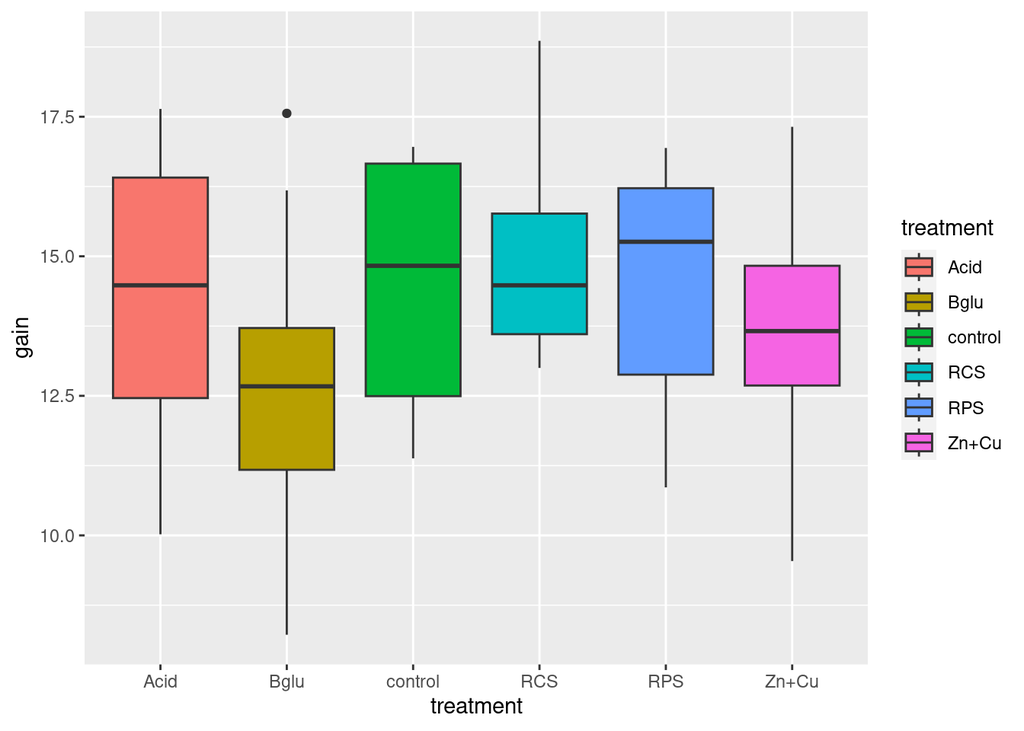

```r
library(tidyverse)

final_shed <- shed %>%
  group_by(pignum) %>%
  mutate(gain = pig_weight[time_point == 21] - pig_weight[time_point == 0]) %>% filter(time_point == 21)  %>% ungroup() %>% select(-c(4:9))

ggplot(final_shed) +
  geom_boxplot( aes(treatment, gain, fill = treatment))
```

3. Compute a wilcox test for control vs. the “Bglu” treatment group

```r
wilcox.test(total_shedding ~ treatment, data = final_shed,
            subset = treatment %in% c("control", "Bglu"))
```

```
##
##  Wilcoxon rank sum exact test
##
## data:  total_shedding by treatment
## W = 23, p-value = 0.04326
## alternative hypothesis: true location shift is not equal to 0
```

## Basics

Using the R Reference Card (and the Help pages, if needed), do the following:

1. Find out how many rows and columns the `iris’ data set has. Figure out at least 2 ways to do this. *Hint: “Variable Information” section on the first page of the reference card!*

```r
nrow(iris)
```

```
## [1] 150
```

```r
ncol(iris)
```

```
## [1] 5
```

```r
dim(iris)
```

```
## [1] 150   5
```

2. Use the `rep` function to construct the following vector: 1 1 2 2 3 3 4 4 5 5 *Hint: “Data Creation” section of the reference card*

```r
rep(1:5, each = 2)
```

```
##  [1] 1 1 2 2 3 3 4 4 5 5
```

3. Use `rep` to construct this vector: 1 2 3 4 5 1 2 3 4 5 1 2 3 4 5

```r
rep(1:5, times = 3)
```

```
##  [1] 1 2 3 4 5 1 2 3 4 5 1 2 3 4 5
```

```r
sum(c(TRUE, TRUE, FALSE, TRUE, FALSE))
```

```
## [1] 3
```

```r
sum(shed$total_shedding < .30)
```

```
## [1] 66
```

2. **More Challenging**: Calculate the sum of the total shedding log10 CFUs of all pigs with a total shedding value of less than 30 log10 CFUs

```r
sum(shed$total_shedding[shed$total_shedding < 30])
```

```
## [1] 1930.403
```

1. Which pigs have a shedding value less than or equal to 30 OR is in the Acid treatment group?

```r
shedding <- final_shed$total_shedding
treatment <- final_shed$treatment
id <- (shedding <= 30 | treatment == "Acid")
final_shed[id,]
```

```
## # A tibble: 15 × 7
##    pignum time_point pig_weight daily_shedding treatment total_shedding  gain
##     <int>      <int>      <dbl>          <dbl> <chr>              <dbl> <dbl>
##  1     97         21       24.9           0    RPS                  0    12.9
##  2    181         21       34.6           3.91 RPS                 23.8  16.9
##  3    321         21       28.8           3.91 RPS                 28.0  13.5
##  4    373         21       33.3           0    RPS                 29.1  16.7
##  5    392         21       29.3           0    RPS                 19.6  16.2
##  6     26         21       23.8           4.61 Acid                35.0  12.3
##  7     52         21       34.7           3.91 Acid                34.0  17.2
##  8    126         21       24.3           3.91 Acid                48.4  11.9
##  9    152         21       29.7           3.91 Acid                48.6  14.6
## 10    178         21       33.3           3.91 Acid                35.8  16.6
## 11    211         21       28.6           0    Acid                30.9  14.4
## 12    348         21       27.2           3.91 Acid                58.5  12.9
## 13    361         21       19.5           0    Acid                40.1  10.0
## 14    378         21       31.6           3.91 Acid                34.0  15.7
## 15    426         21       35.0           3.91 Acid                33.5  17.6
```

## Data Structures

1. In row_matrix, change ‘byrow = FALSE’ to see what happens

```r
matrix(
  c(1, 2, 3, 4, 5, 6, 7, 8, 9),
  nrow = 3,
  ncol = 3,
  byrow = FALSE
)
```

```
##      [,1] [,2] [,3]
## [1,]    1    4    7
## [2,]    2    5    8
## [3,]    3    6    9
```

2. Recreate this matrix.

```r
matrix(c(2,4,6,8,10,12), nrow=3, ncol = 2, byrow = FALSE)
```

```
##      [,1] [,2]
## [1,]    2    8
## [2,]    4   10
## [3,]    6   12
```

1. Make a data frame with column 1: 1,2,3,4,5,6 and column 2: a,b,a,b,a,b

```r
mydf <- data.frame(col1 = 1:6, col2 = rep(c("a", "b"), times = 3))
```

2. Select only rows with value “a” in column 2 using logical vector

```r
mydf[mydf$col2 == "a",]
```

```
##   col1 col2
## 1    1    a
## 3    3    a
## 5    5    a
```

```r
names(mydf) <- c("Bulldogs", "Tigers")
```

4. `mtcars` is a built in data set like `iris`: Extract the 4th row of the `mtcars` data.

```r
mtcars[4,]
```

```
##                 mpg cyl disp  hp drat    wt  qsec vs am gear carb
## Hornet 4 Drive 21.4   6  258 110 3.08 3.215 19.44  1  0    3    1
```

5. Create another column in the flower data frame, that is the sum of Sepal Width, Sepal Length, Petal Width and Petal Length.

```r
flower <- iris

total <- flower$Sepal.Length + flower$Sepal.Width + flower$Petal.Length + flower$Petal.Width

flower2 <- data.frame(flower, total)

head(flower2)
```

```
##   Sepal.Length Sepal.Width Petal.Length Petal.Width Species total
## 1          5.1         3.5          1.4         0.2  setosa  10.2
## 2          4.9         3.0          1.4         0.2  setosa   9.5
## 3          4.7         3.2          1.3         0.2  setosa   9.4
## 4          4.6         3.1          1.5         0.2  setosa   9.4
## 5          5.0         3.6          1.4         0.2  setosa  10.2
## 6          5.4         3.9          1.7         0.4  setosa  11.4
```

6. Step Further. Create a data frame of observations where Sepal Length is greater than 6. Then create another column in the this data frame, that is the sum of Sepal Width and Sepal Length

```r
flower_s <- flower[flower$Sepal.Length>6, ]

total_s <- flower_s$Sepal.Length + flower_s$Sepal.Width

head(data.frame(flower_s, total_s))
```

```
##    Sepal.Length Sepal.Width Petal.Length Petal.Width    Species total_s
## 51          7.0         3.2          4.7         1.4 versicolor    10.2
## 52          6.4         3.2          4.5         1.5 versicolor     9.6
## 53          6.9         3.1          4.9         1.5 versicolor    10.0
## 55          6.5         2.8          4.6         1.5 versicolor     9.3
## 57          6.3         3.3          4.7         1.6 versicolor     9.6
## 59          6.6         2.9          4.6         1.3 versicolor     9.5
```

1. Create a list containing a vector and a 2x3 data frame

```r
mylist <- list(vec = 1:6, df = data.frame(x = 1:2, y = 3:4, z = 5:6))
```

2. Use indexing to select the data frame from your list

```r
mylist[[2]]
```

```
##   x y z
## 1 1 3 5
## 2 2 4 6
```

3. Use further indexing to select the first row from the data frame in your list

```r
mylist[[2]][1,]
```

```
##   x y z
## 1 1 3 5
```

1. View the top 8 rows of mtcars data

```r
head(mtcars, n = 8)
```

```
##                    mpg cyl  disp  hp drat    wt  qsec vs am gear carb
## Mazda RX4         21.0   6 160.0 110 3.90 2.620 16.46  0  1    4    4
## Mazda RX4 Wag     21.0   6 160.0 110 3.90 2.875 17.02  0  1    4    4
## Datsun 710        22.8   4 108.0  93 3.85 2.320 18.61  1  1    4    1
## Hornet 4 Drive    21.4   6 258.0 110 3.08 3.215 19.44  1  0    3    1
## Hornet Sportabout 18.7   8 360.0 175 3.15 3.440 17.02  0  0    3    2
## Valiant           18.1   6 225.0 105 2.76 3.460 20.22  1  0    3    1
## Duster 360        14.3   8 360.0 245 3.21 3.570 15.84  0  0    3    4
## Merc 240D         24.4   4 146.7  62 3.69 3.190 20.00  1  0    4    2
```

2. What type of object is the mtcars data set?

```r
str(mtcars)
```

```
## 'data.frame':    32 obs. of  11 variables:
##  $ mpg : num  21 21 22.8 21.4 18.7 18.1 14.3 24.4 22.8 19.2 ...
##  $ cyl : num  6 6 4 6 8 6 8 4 4 6 ...
##  $ disp: num  160 160 108 258 360 ...
##  $ hp  : num  110 110 93 110 175 105 245 62 95 123 ...
##  $ drat: num  3.9 3.9 3.85 3.08 3.15 2.76 3.21 3.69 3.92 3.92 ...
##  $ wt  : num  2.62 2.88 2.32 3.21 3.44 ...
##  $ qsec: num  16.5 17 18.6 19.4 17 ...
##  $ vs  : num  0 0 1 1 0 1 0 1 1 1 ...
##  $ am  : num  1 1 1 0 0 0 0 0 0 0 ...
##  $ gear: num  4 4 4 3 3 3 3 4 4 4 ...
##  $ carb: num  4 4 1 1 2 1 4 2 2 4 ...
```

3. How many rows are in iris data set? (try finding this using dim or indexing + length)

```r
dim(iris)
```

```
## [1] 150   5
```

4. Summarize the values in each column in iris data set

```r
summary(iris)
```

```
##   Sepal.Length    Sepal.Width     Petal.Length    Petal.Width
##  Min.   :4.300   Min.   :2.000   Min.   :1.000   Min.   :0.100
##  1st Qu.:5.100   1st Qu.:2.800   1st Qu.:1.600   1st Qu.:0.300
##  Median :5.800   Median :3.000   Median :4.350   Median :1.300
##  Mean   :5.843   Mean   :3.057   Mean   :3.758   Mean   :1.199
##  3rd Qu.:6.400   3rd Qu.:3.300   3rd Qu.:5.100   3rd Qu.:1.800
##  Max.   :7.900   Max.   :4.400   Max.   :6.900   Max.   :2.500
##        Species
##  setosa    :50
##  versicolor:50
##  virginica :50
##
##
##
```

## Packages and Programming

1. Create a function that takes numeric input and provides the mean and a 95% confidence interval for the mean for the data (the t.test function could be useful)

```r
mean_and_ci <- function(x) {
    themean <- mean(x)
    theci <- t.test(x)$conf.int

    return(list(mean = themean, ci = theci))
}
```

2. Add checks to your function to make sure the data is either numeric or logical. If it is logical convert it to numeric.

```r
mean_and_ci <- function(x) {
    if (!is.numeric(x) && !is.logical(x)) stop("Need logical or numeric data")

    x <- as.numeric(x)

    themean <- mean(x)
    theci <- t.test(x)$conf.int

    return(list(mean = themean, ci = theci))
}
```

3. Loop over the columns of the diamonds data set and apply your function to all of the numeric columns.

```r
for (i in colnames(diamonds)) {
  if (is.numeric(diamonds[,i,drop = TRUE])) {print(mean_and_ci(diamonds[,i,drop = TRUE]))}
  else {print("nope")}
}
```

```
## $mean
## [1] 0.7979397
##
## $ci
## [1] 0.7939395 0.8019400
## attr(,"conf.level")
## [1] 0.95
##
## [1] "nope"
## [1] "nope"
## [1] "nope"
## $mean
## [1] 61.7494
##
## $ci
## [1] 61.73731 61.76150
## attr(,"conf.level")
## [1] 0.95
##
## $mean
## [1] 57.45718
##
## $ci
## [1] 57.43833 57.47604
## attr(,"conf.level")
## [1] 0.95
##
## $mean
## [1] 3932.8
##
## $ci
## [1] 3899.132 3966.467
## attr(,"conf.level")
## [1] 0.95
##
## $mean
## [1] 5.731157
##
## $ci
## [1] 5.721690 5.740624
## attr(,"conf.level")
## [1] 0.95
##
## $mean
## [1] 5.734526
##
## $ci
## [1] 5.724887 5.744165
## attr(,"conf.level")
## [1] 0.95
##
## $mean
## [1] 3.538734
##
## $ci
## [1] 3.532778 3.544689
## attr(,"conf.level")
## [1] 0.95
```